# Kuliah 2

# Library

```r
library(readxl) # membaca file excel
library(lmtest) # uji diagnostik pada model regresi
library(orcutt) # membuat model regresi Cochrane-Orcutt
```

# Data

## Input Data

```r
data1<-read_xlsx("C:/Users/ATIKAH MAULINA/OneDrive/Documents/STK 5/MPDW/MPDW/Pertemuan 3/Kuliah 2.xlsx", sheet=1)

head(data1) # melihat beberapa baris data
```

```
## # A tibble: 6 × 3
##   Period `Market Share` Price
##    <dbl>          <dbl> <dbl>
## 1      1           3.63  0.97
## 2      2           4.2   0.95
## 3      3           3.33  0.99
## 4      4           4.54  0.91
## 5      5           2.89  0.98
## 6      6           4.87  0.9
```

```r
# merapihkan data
dt <- as.data.frame(data1)
colnames(dt) <- c("periode", "share", "price")
dt
```

```
##    periode share price
## 1        1  3.63  0.97
## 2        2  4.20  0.95
## 3        3  3.33  0.99
## 4        4  4.54  0.91
## 5        5  2.89  0.98
## 6        6  4.87  0.90
## 7        7  4.90  0.89
## 8        8  5.29  0.86
## 9        9  6.18  0.85
## 10      10  7.20  0.82
## 11      11  7.25  0.79
## 12      12  6.09  0.83
## 13      13  6.80  0.81
## 14      14  8.65  0.77
## 15      15  8.43  0.76
## 16      16  8.29  0.80
## 17      17  7.18  0.83
## 18      18  7.90  0.79
## 19      19  8.45  0.76
## 20      20  8.23  0.78
```

## Eksplorasi Data

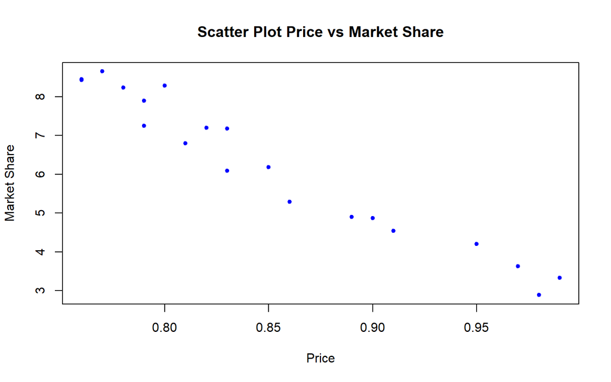

```r
plot(dt$price, dt$share, pch = 20, col = "blue",
     main = "Scatter Plot Price vs Market Share",
     xlab = "Price", ylab = "Market Share")
```

```r
# Korelasi
cor(dt$price, dt$share)
```

```
## [1] -0.9752564
```

Nilai korelasi antara price dan market share menunjukkan hubungan linear yang sangat kuat dan negatif. Artinya, semakin tinggi harga (price), semakin rendah market share, begitu pula sebaliknya.

# Model Regresi Awal

```r
model <- lm(share ~ price, data = dt)
summary(model)
```

```
##
## Call:
## lm(formula = share ~ price, data = dt)
##
## Residuals:
##      Min       1Q   Median       3Q      Max
## -0.73068 -0.29764 -0.00966  0.30224  0.81193
##
## Coefficients:
##             Estimate Std. Error t value Pr(>|t|)
## (Intercept)   26.910      1.110   24.25 3.39e-15 ***
## price        -24.290      1.298  -18.72 3.02e-13 ***
## ---
## Signif. codes:  0 '***' 0.001 '**' 0.01 '*' 0.05 '.' 0.1 ' ' 1
##
## Residual standard error: 0.4287 on 18 degrees of freedom
## Multiple R-squared:  0.9511, Adjusted R-squared:  0.9484
## F-statistic: 350.3 on 1 and 18 DF,  p-value: 3.019e-13
```

```r
sisaan <- residuals(model)
fitValue <- predict(model)
```

Nilai p-value = 3,02e-13 < 0,05 menunjukkan bahwa setiap kenaikan 1 satuan price akan menurunkan market share sebesar 24,290 satuan, dengan asumsi faktor lain tetap. Nilai R-squared menunjukkan model ini mampu menjelaskan 95,11% variasi market share.

## Plot Sisaan

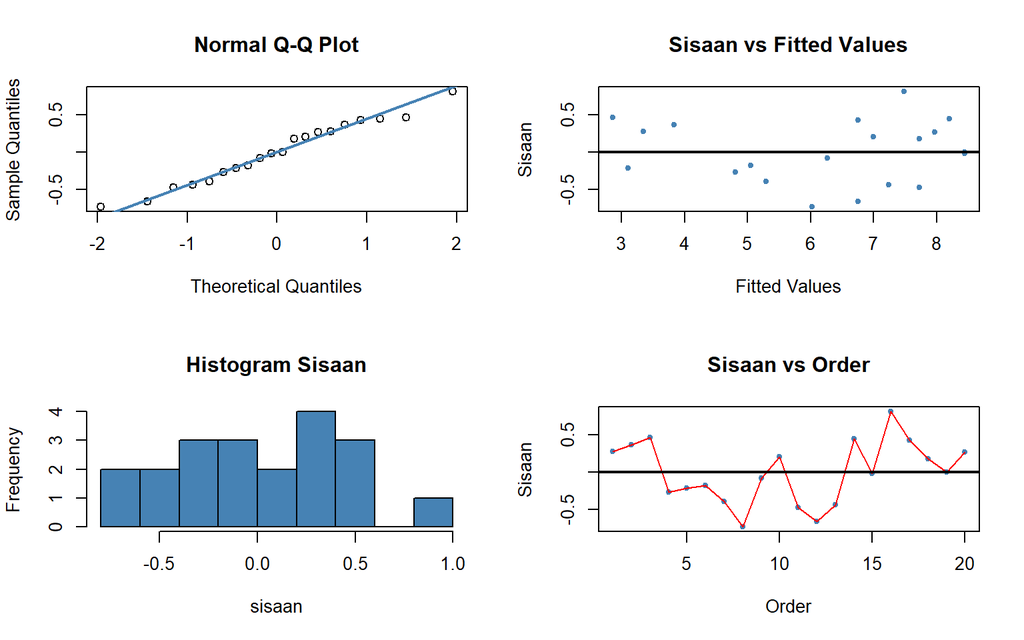

```r
par(mfrow = c(2,2))
qqnorm(sisaan)
qqline(sisaan, col = "steelblue", lwd = 2)
plot(fitValue, sisaan, col = "steelblue", pch = 20,
     xlab = "Fitted Values", ylab = "Sisaan",
     main = "Sisaan vs Fitted Values")
abline(a = 0, b = 0, lwd = 2)
hist(sisaan, col = "steelblue", main = "Histogram Sisaan")
plot(seq(1, nrow(dt), 1), sisaan, col = "steelblue", pch = 20,
     xlab = "Order", ylab = "Sisaan", main = "Sisaan vs Order")
lines(seq(1, nrow(dt), 1), sisaan, col = "red")
abline(a = 0, b = 0, lwd = 2)
```

# Uji Normalitas Sisaan

H0: sisaan normal  
H1: sisaan tidak normal

```r
shapiro.test(sisaan)
```

```
##
##  Shapiro-Wilk normality test
##
## data:  sisaan
## W = 0.9744, p-value = 0.8437
```

Nilai p-value = 0,8437 > 0,05, maka H0 tidak ditolak, sehingga dapat disimpulkan bahwa sisaan model regresi menyebar normal. Asumsi normalitas sisaan terpenuhi.

# ACF & PACF sisaan

ACF & PACF adalah pengukuran korelasi langsung antara suatu data dengan data pada lag tertentu (autokorelasi pada sisaan).

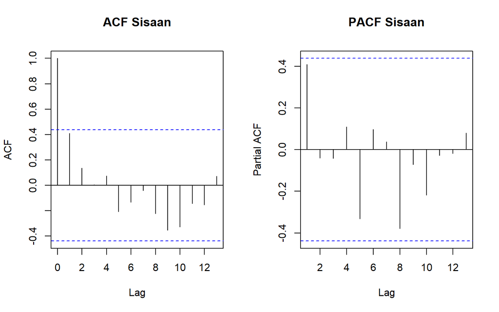

```r
par(mfrow = c(1,2))
acf(sisaan, main = "ACF Sisaan")
pacf(sisaan, main = "PACF Sisaan")
```

Plot ACF menunjukkan pola yang mengindikasikan kemungkinan adanya autokorelasi lag pertama pada sisaan karena berada tepat di bawah batas signifikansi (garis putus-putus biru) yang perlu dikonfirmasi lebih lanjut dengan uji formal (Durbin-Watson).

# Uji Durbin-Watson (Autokorelasi)

H0: tidak ada autokorelasi H1: ada autokorelasi

```r
dwtest(model)
```

```
##
##  Durbin-Watson test
##
## data:  model
## DW = 1.1358, p-value = 0.009813
## alternative hypothesis: true autocorrelation is greater than 0
```

Nilai p-value 0,009813 < 0,05, maka H0 ditolak, sehingga dapat disimpulkan bahwa terdapat autokorelasi positif pada sisaan model regresi. Hal ini melanggar salah satu asumsi OLS (Ordinary Least Squares), sehingga perlu dilakukan penanganan autokorelasi.

# Penanganan Autokorelasi

## Cara Manual

```r
y <- dt$share
x <- dt$price
```

## Metode Cochrane-Orcutt

```r
rho <- sum(sisaan[-1] * sisaan[-length(sisaan)]) / sum(sisaan[-length(sisaan)]^2)
```

```r
for (iter in 1:50) {
  y.trans <- y[-1] - rho * y[-length(y)]
  x.trans <- x[-1] - rho * x[-length(x)]
  mod.trans <- lm(y.trans ~ x.trans)
   b0star <- coef(mod.trans)[1]
  b1 <- coef(mod.trans)[2]
  b0 <- b0star / (1 - rho)
  e.orig <- y - b0 - b1 * x
  rho.baru <- sum(e.orig[-1] * e.orig[-length(e.orig)]) / sum(e.orig[-length(e.orig)]^2)

  if (abs(rho.baru - rho) < 1e-6) { rho <- rho.baru; break }
  rho <- rho.baru
}
```

```r
cat("Rho optimum (Cochrane-Orcutt):", rho, "\n")
```

```
## Rho optimum (Cochrane-Orcutt): 0.4252321
```

```r
y.trans <- y[-1] - rho * y[-length(y)]
x.trans <- x[-1] - rho * x[-length(x)]
modelCO <- lm(y.trans ~ x.trans)
summary(modelCO)
```

```
##
## Call:
## lm(formula = y.trans ~ x.trans)
##
## Residuals:
##      Min       1Q   Median       3Q      Max
## -0.55508 -0.25069 -0.05506  0.25007  0.83017
##
## Coefficients:
##             Estimate Std. Error t value Pr(>|t|)
## (Intercept)  15.3590     0.9385   16.36 7.71e-12 ***
## x.trans     -24.0841     1.9385  -12.42 5.90e-10 ***
## ---
## Signif. codes:  0 '***' 0.001 '**' 0.01 '*' 0.05 '.' 0.1 ' ' 1
##
## Residual standard error: 0.3955 on 17 degrees of freedom
## Multiple R-squared:  0.9008, Adjusted R-squared:  0.895
## F-statistic: 154.4 on 1 and 17 DF,  p-value: 5.903e-10
```

```r
b0 <- coef(modelCO)[1] / (1 - rho)
b1 <- coef(modelCO)[2]
cat("Model asli: share =", round(b0,4), "+ (", round(b1,4), ") * price\n")
```

```
## Model asli: share = 26.7221 + ( -24.0841 ) * price
```

```r
# pemeriksaan kembali (seharusnya p-value >= 0.05)
dwtest(modelCO)
```

```
##
##  Durbin-Watson test
##
## data:  modelCO
## DW = 1.958, p-value = 0.4151
## alternative hypothesis: true autocorrelation is greater than 0
```

## Cara Langsung

```r
modelCO <- cochrane.orcutt(model)
modelCO
```

```
## Cochrane-orcutt estimation for first order autocorrelation
##
## Call:
## lm(formula = share ~ price, data = dt)
##
##  number of interaction: 8
##  rho 0.425232
##
## Durbin-Watson statistic
## (original):    1.13582 , p-value: 9.813e-03
## (transformed): 1.95804 , p-value: 4.151e-01
##
##  coefficients:
## (Intercept)       price
##    26.72209   -24.08413
```

```r
# cek lagi (seharusnya p-value >= 0.05)
dwtest(modelCO)
```

```
##
##  Durbin-Watson test
##
## data:  modelCO
## DW = 1.958, p-value = 0.4151
## alternative hypothesis: true autocorrelation is greater than 0
```

## Metode Hildreth-Lu

```r
hildreth.lu.func <- function(r, model){
  x <- model.matrix(model)[,-1]
  y <- model.response(model.frame(model))
  n <- length(y)
  t <- 2:n
  y <- y[t] - r*y[t-1]
  x <- x[t] - r*x[t-1]
  return(lm(y~x))
}
```

```r
r <- seq(0.1, 0.9, by = 0.1)
tab <- data.frame(rho = r, SSE = sapply(r, function(i) deviance(hildreth.lu.func(i, model))))
tab[order(tab$SSE), ]
```

```
##   rho      SSE
## 4 0.4 2.661188
## 5 0.5 2.674924
## 3 0.3 2.705239
## 6 0.6 2.741983
## 2 0.2 2.810498
## 7 0.7 2.858804
## 1 0.1 2.979074
## 8 0.8 3.026489
## 9 0.9 3.252863
```

```r
rOpt <- seq(0.1, 0.9, by = 0.001)
tabOpt <- data.frame(rho = rOpt, SSE = sapply(rOpt, function(i) deviance(hildreth.lu.func(i, model))))
best <- tabOpt[which.min(tabOpt$SSE), ]
best
```

```
##       rho      SSE
## 326 0.425 2.659368
```

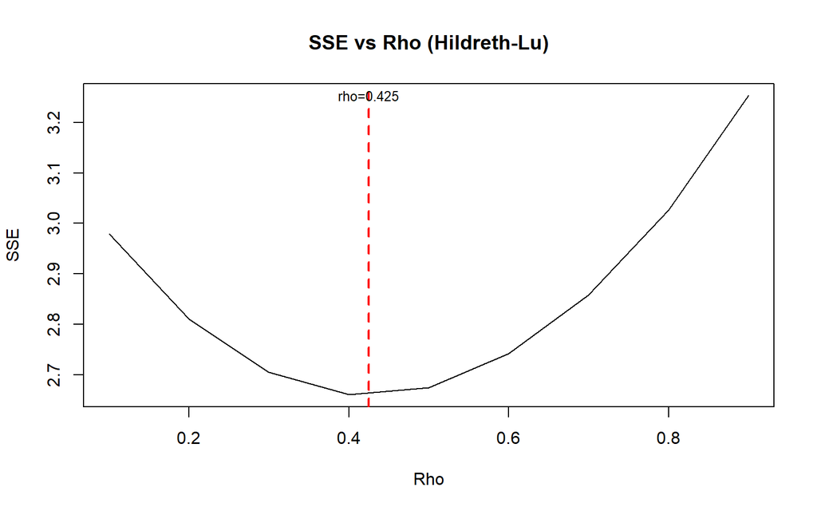

```r
plot(tab$SSE ~ tab$rho, type = "l", xlab = "Rho", ylab = "SSE",
     main = "SSE vs Rho (Hildreth-Lu)")
abline(v = best$rho, lty = 2, col = "red", lwd = 2)
text(x = best$rho, y = max(tab$SSE), labels = paste0("rho=", best$rho), cex = 0.8)
```

Hasilnya diperoleh rho optimum sebesar 0,425 dengan SSE terkecil sebesar 2,659368, yang konsisten dengan hasil metode Cochrane-Orcutt (rho = 0,4252).

```r
modelHL <- hildreth.lu.func(best$rho, model)
summary(modelHL)
```

```
##
## Call:
## lm(formula = y ~ x)
##
## Residuals:
##      Min       1Q   Median       3Q      Max
## -0.55517 -0.25066 -0.05505  0.25010  0.83017
##
## Coefficients:
##             Estimate Std. Error t value Pr(>|t|)
## (Intercept)  15.3655     0.9387   16.37 7.68e-12 ***
## x           -24.0848     1.9380  -12.43 5.88e-10 ***
## ---
## Signif. codes:  0 '***' 0.001 '**' 0.01 '*' 0.05 '.' 0.1 ' ' 1
##
## Residual standard error: 0.3955 on 17 degrees of freedom
## Multiple R-squared:  0.9008, Adjusted R-squared:  0.895
## F-statistic: 154.4 on 1 and 17 DF,  p-value: 5.88e-10
```

```r
# pemeriksaan kembali
dwtest(modelHL)
```

```
##
##  Durbin-Watson test
##
## data:  modelHL
## DW = 1.9577, p-value = 0.4148
## alternative hypothesis: true autocorrelation is greater than 0
```

Uji Durbin-Watson pada model hasil transformasi menghasilkan p-value = 0,4148 > 0,05, maka H0 tidak ditolak. Artinya, autokorelasi pada sisaan juga sudah teratasi dengan metode ini. Kedua metode penanganan autokorelasi memberikan nilai rho yang hampir sama, dapat disimpulkan bahwa hasil estimasi rho ini robust/dapat diandalkan.

# Perbandingan Akurasi

```r
sseModelawal <- anova(model)$`Sum Sq`[-1]
sseModelCO   <- sum(modelCO$residuals^2)
sseModelHL   <- anova(modelHL)$`Sum Sq`[-1]
```

```r
n <- nrow(dt)
mseModelawal <- sseModelawal / n
mseModelCO   <- sseModelCO / n
mseModelHL   <- sseModelHL / n
```

```r
akurasi <- matrix(c(sseModelawal, sseModelCO, sseModelHL,
                     mseModelawal, mseModelCO, mseModelHL),
                   nrow = 2, ncol = 3, byrow = TRUE)
colnames(akurasi) <- c("Model Awal", "Cochrane-Orcutt", "Hildreth-Lu")
row.names(akurasi) <- c("SSE", "MSE")
akurasi
```

```
##     Model Awal Cochrane-Orcutt Hildreth-Lu
## SSE  3.3082574        3.316041   2.6593683
## MSE  0.1654129        0.165802   0.1329684
```

# Data

## Input Data

```r
data2<-read_xlsx("C:/Users/ATIKAH MAULINA/OneDrive/Documents/STK 5/MPDW/MPDW/Pertemuan 3/Kuliah 2.xlsx", sheet=2)

head(data2) # melihat beberapa baris data
```

```
## # A tibble: 6 × 3
##    Year Sales Advertising
##   <dbl> <dbl>       <dbl>
## 1  1975  11.7         9.4
## 2  1976  12           9.6
## 3  1977  12.3        10
## 4  1978  12.8        10.4
## 5  1979  13.1        10.8
## 6  1980  13.6        10.9
```

```r
# merapihkan format
dt1 <- as.data.frame(data2)
colnames(dt1) <- c("tahun", "sales", "advertising")
dt1
```

```
##    tahun sales advertising
## 1   1975  11.7         9.4
## 2   1976  12.0         9.6
## 3   1977  12.3        10.0
## 4   1978  12.8        10.4
## 5   1979  13.1        10.8
## 6   1980  13.6        10.9
## 7   1981  13.9        11.7
## 8   1982  14.4        12.2
## 9   1983  14.7        12.5
## 10  1984  15.3        12.9
## 11  1985  15.5        13.0
## 12  1986  15.8        13.2
## 13  1987  16.1        13.8
## 14  1988  16.6        14.2
```

[output cut: 26 more lines]

# Eksplorasi Data

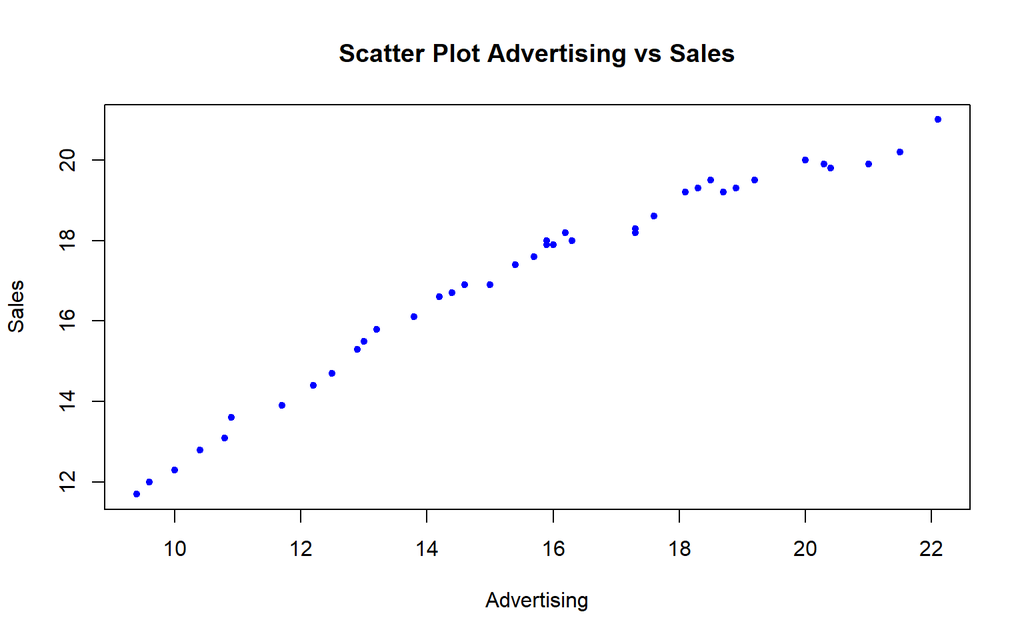

```r
plot(dt1$advertising, dt1$sales, pch = 20, col = "blue",
     main = "Scatter Plot Advertising vs Sales",
     xlab = "Advertising", ylab = "Sales")
```

```r
# Korelasi
cor(dt1$advertising, dt1$sales)
```

```
## [1] 0.9797631
```

Nilai korelasi antara advertising dan sales menunjukkan hubungan linear yang sangat kuat dan positif. Artinya, semakin tinggi biaya advertising, semakin tinggi pula sales yang dihasilkan.

# Model Regresi Awal

```r
model1 <- lm(sales ~ advertising, data = dt1)
summary(model1)
```

```
##
## Call:
## lm(formula = sales ~ advertising, data = dt1)
##
## Residuals:
##      Min       1Q   Median       3Q      Max
## -1.02398 -0.39609  0.00937  0.46522  0.74938
##
## Coefficients:
##             Estimate Std. Error t value Pr(>|t|)
## (Intercept)  5.96911    0.37907   15.75   <2e-16 ***
## advertising  0.70953    0.02351   30.17   <2e-16 ***
## ---
## Signif. codes:  0 '***' 0.001 '**' 0.01 '*' 0.05 '.' 0.1 ' ' 1
##
## Residual standard error: 0.5247 on 38 degrees of freedom
## Multiple R-squared:  0.9599, Adjusted R-squared:  0.9589
## F-statistic: 910.5 on 1 and 38 DF,  p-value: < 2.2e-16
```

```r
sisaan1 <- residuals(model1)
fitValue <- predict(model1)
```

Nilai p-value < 2e-16 menunjukkan bahwa setiap kenaikan 1 satuan biaya advertising akan meningkatkan sales sebesar 0,70953 satuan. Nilai R-squared sebesar 0,9599 menunjukkan model ini mampu menjelaskan 95,99% variasi sales.

## Plot Sisaan

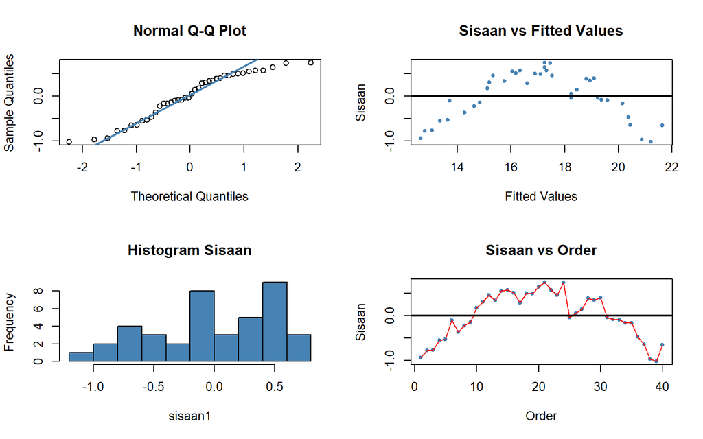

```r
par(mfrow = c(2,2))
qqnorm(sisaan1)
qqline(sisaan1, col = "steelblue", lwd = 2)
plot(fitValue, sisaan1, col = "steelblue", pch = 20,
     xlab = "Fitted Values", ylab = "Sisaan",
     main = "Sisaan vs Fitted Values")
abline(a = 0, b = 0, lwd = 2)
hist(sisaan1, col = "steelblue", main = "Histogram Sisaan")
plot(seq(1, nrow(dt1), 1), sisaan1, col = "steelblue", pch = 20,
     xlab = "Order", ylab = "Sisaan", main = "Sisaan vs Order")
lines(seq(1, nrow(dt1), 1), sisaan1, col = "red")
abline(a = 0, b = 0, lwd = 2)
```

# Uji Normalitas Sisaan

```r
shapiro.test(sisaan1)
```

```
##
##  Shapiro-Wilk normality test
##
## data:  sisaan1
## W = 0.93744, p-value = 0.02837
```

Nilai p-value = 0,02837 < 0,05, maka H0 ditolak, sehingga dapat disimpulkan bahwa **sisaan model regresi tidak menyebar normal**.